# Ames, Iowa Housing Data

We notice the relationship between the amount of area above the ground and the sales price changes depending on the number of stories of the house.

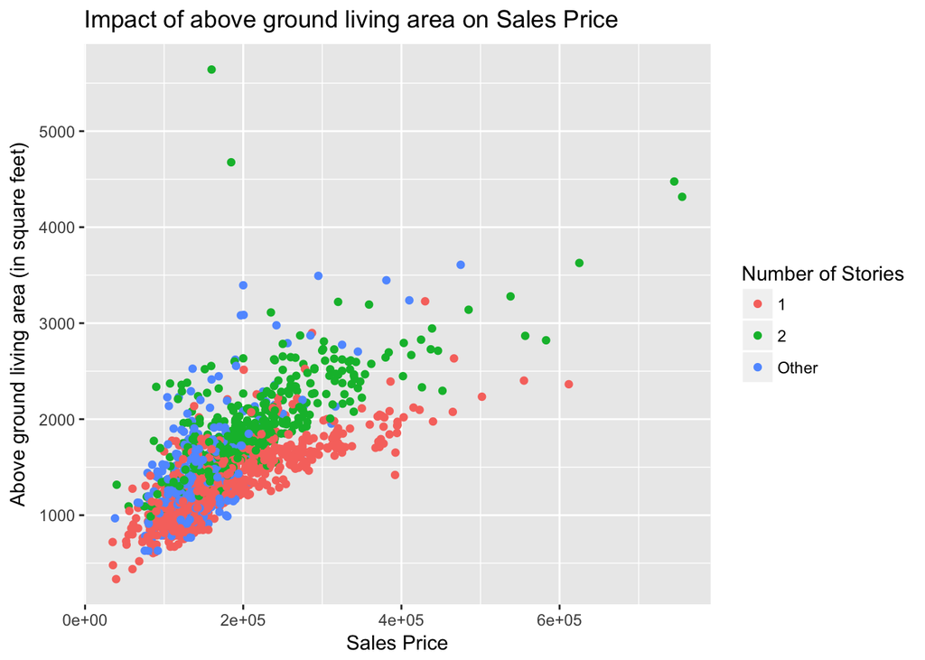

```r
library(ggplot2)

train$story <- ifelse(train$HouseStyle == "1Story", 1, ifelse(train$HouseStyle == "2Story", 2, "Other"))

ggplot(train, aes(x = train$SalePrice, y = train$GrLivArea)) + geom_point(aes(colour = factor(train$story))) + xlab("Sales Price") +
  ylab("Above ground living area (in square feet)") + ggtitle("Impact of above ground living area on Sales Price") + scale_colour_discrete("Number of Stories")
```

We also notice the different shapes of the histogram displaying the frequency of the different priced homes depending on the years surrounding the United States Housing Bubble.

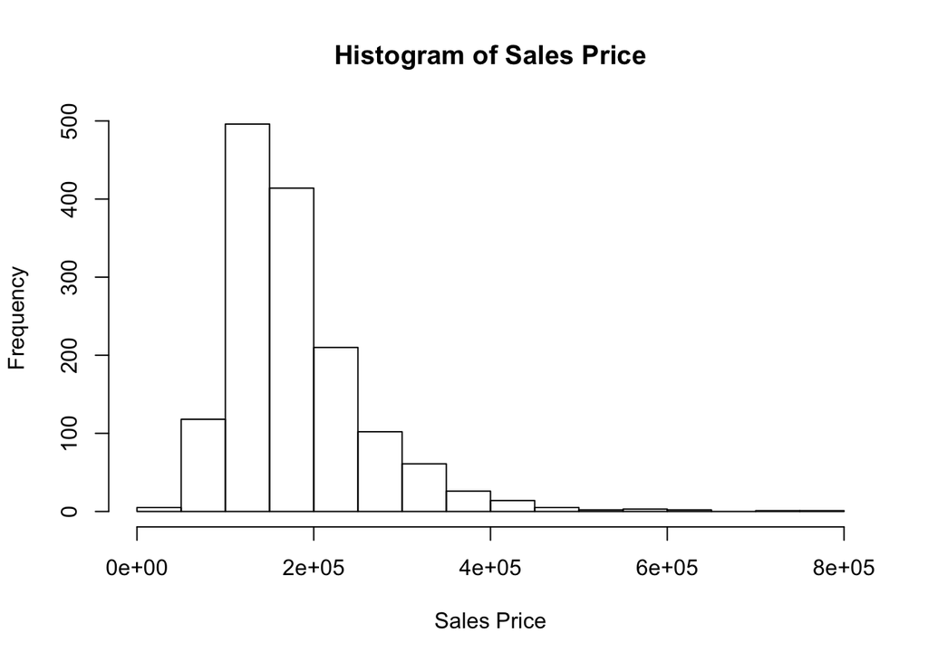

```r
library(ggplot2)
# Histogram of the Sale's Price
hist(train$SalePrice, main = "Histogram of Sales Price", xlab = "Sales Price", ylab = "Frequency")
```

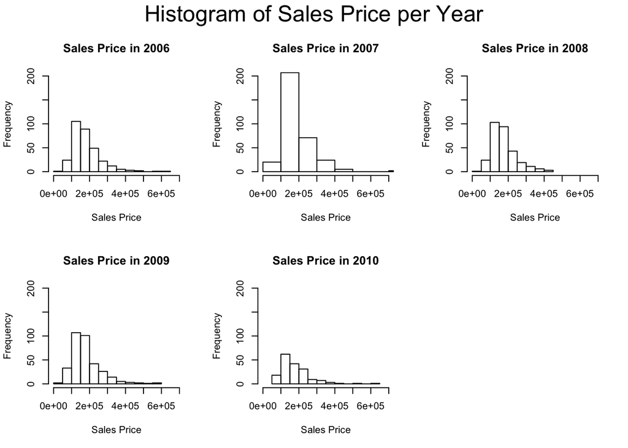

```r
# Histograms of Sales Price depending on the year
par(mfrow=c(2,3), oma = c(0, 0, 2, 0))
hist(train$SalePrice[which(train$YrSold == 2006)], xlim = c(0, 700000), ylim = c(0, 200), main = "Sales Price in 2006", xlab = "Sales Price")
hist(train$SalePrice[which(train$YrSold == 2007)], xlim = c(0, 700000), ylim = c(0, 200), main = "Sales Price in 2007", xlab = "Sales Price")
hist(train$SalePrice[which(train$YrSold == 2008)], xlim = c(0, 700000), ylim = c(0, 200), main = "Sales Price in 2008", xlab = "Sales Price")
hist(train$SalePrice[which(train$YrSold == 2009)], xlim = c(0, 700000), ylim = c(0, 200), main = "Sales Price in 2009", xlab = "Sales Price")
hist(train$SalePrice[which(train$YrSold == 2010)], xlim = c(0, 700000), ylim = c(0, 200), main = "Sales Price in 2010", xlab = "Sales Price")
mtext("Histogram of Sales Price per Year", outer = TRUE, cex = 1.5)
```

# Project Objectives and Questions

Our project objectives are to address the following questions.

1. Which predictors are the most important in predicting the price of a home?

We plan on using linear regression, LASSO, and PCA for dimension reduction as well as possibly exploring other feature selection techniques if needed.

2. Do different neighborhoods affect housing prices?

We assume the answer to this question is “Yes”, and we plan to discover how. We can use linear regression to identify the important how the different neighborhoods affect the housing prices as well as a preform a spacial cluster analysis on the data.

3. Are there significant temporal trends?

We suspect that there will be interesting temporal trends since this dataset includes information from 2006 until 2010, i.e., it contains information about housing prices before, during, and after the housing bubble. We are interested in discovering whether there will be major differences between home price prediction models restricted to certain years, and we aim to explain these possible differences by events which occurred in each of those years.

4. Can we produce one relatively accurate price prediction model?

We will use a variety of techniques including linear regression, random forests, and cluster analysis to take into consideration the location of the home as well as temporal trends. We will take the previous responses into consideration when creating our final model.

5. How accurate is our prediction model when used to predict the prices of 1-story homes versus 2-story homes?

We will restrict our dataset to only 1-story/2-story homes and test our model using linear regression.